# Plating roots of crop species

Thoenen et al. AMPO formation

Lisa Thönen

2024-05-13

### Background

We conducted this experiment to investigate if bacterial community size and the ratio of AMPO producing bacteria differs between plants producing different amounts of benzoxazinoids.

We used WT and bx1 maize to investigate if this ratio differs between the genotypes in the root, rhizosphere and soil.

To investigate if this effect is observed on other plant species we tested wheat (produces less benzoxazinoids and the majority are non-methylated) and non-BX producing species medicago, brassica and arabidopsis.

### Materials and methods

Plants were grown in Changins field soil for 7 weeks and fertilized. Maize and brassica were grown in 1 L pots, medicago and wheat in 2 L pots and Arabidopsis in 200 ml pots.

For maize we harvested roots, rhizosphere and soil of 6 week old maize plants grown in field soil. For the other plant species we only harvested the roots. The dirty roots were washed in autoclaved water twice and dried on paper. The root samples were cut into small pieces, transferred to 10 ml MgCl2 + Tween 20 and homogenized with the polytron. The tubes were weighed to assess the root weight. Rhizosphere samples were collected by cutting a root segment and vigourously shaking in 10 ml MgCl2 + Tween 20.

To quantify the amount of bacteria which are able to metabolize MBOA to a red pigment, 50 ul of the root samples were plated at a dilution of 1:100 and the rhizosphere samples at a dilution of 1:1000 and incubated for 10 days at room temperature. All colonies were counted and red counts were separately recorded.

Community size: counted after 3d and after 6d

AMPO producing bacteria: counted after 10d and a second picture after 18d

### Important results

*Community size* More CFUs on bx1 than on WT rhizo and soil. More CFUs on wheat compared to the other species.

*AMPO producing bacteria* Higher ratio of AMPO producing bacteria on WT than on bx1 roots, rhizosphere and soil. Higher ratio of AMPO producing bacteria on maize than on all other species producing less and other benzoxazinoids.

### Conclusions

AMPO producing bacteria are enriched on benzoxazinoid producing roots.

# Community size

CFU count after 6 d on TSB + Chex

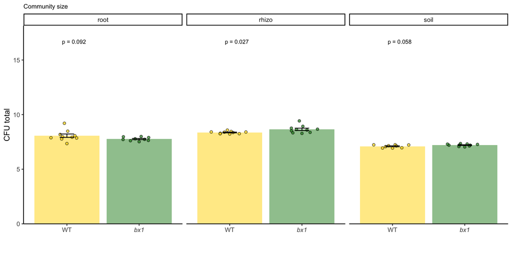

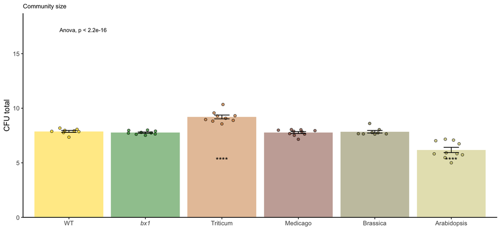

# AMPO-forming bacteria

Root

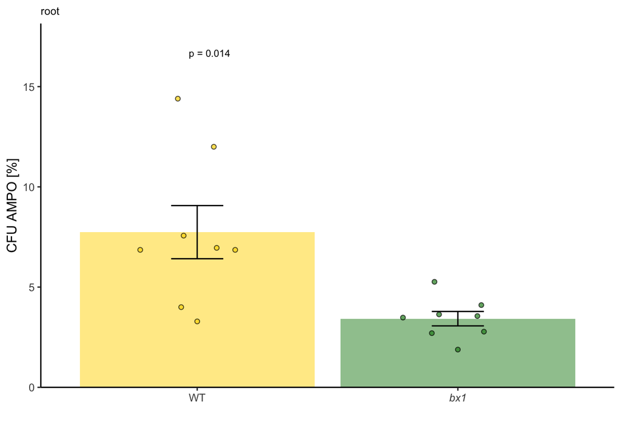

Rhizosphere

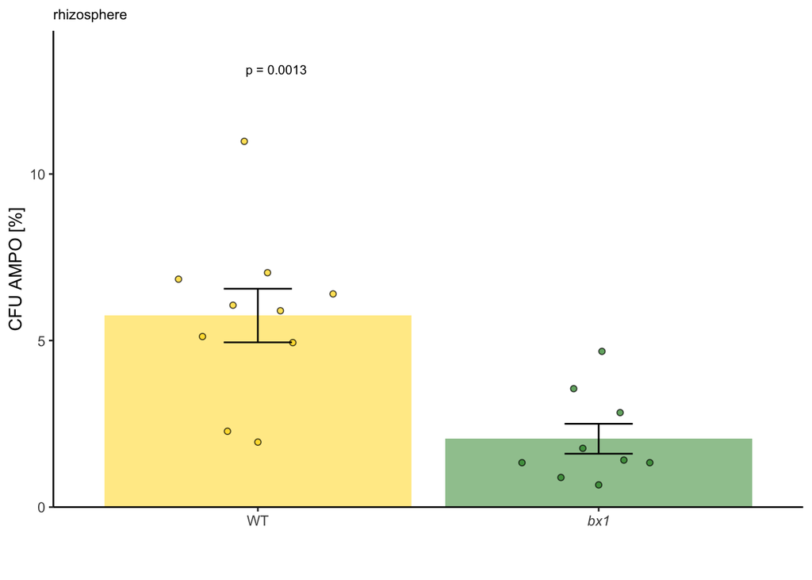

Soil

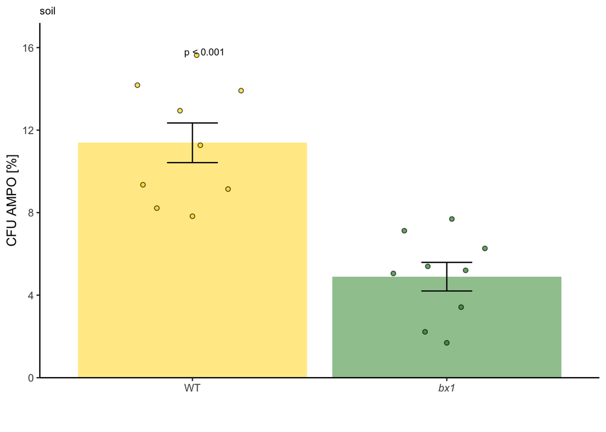

Species

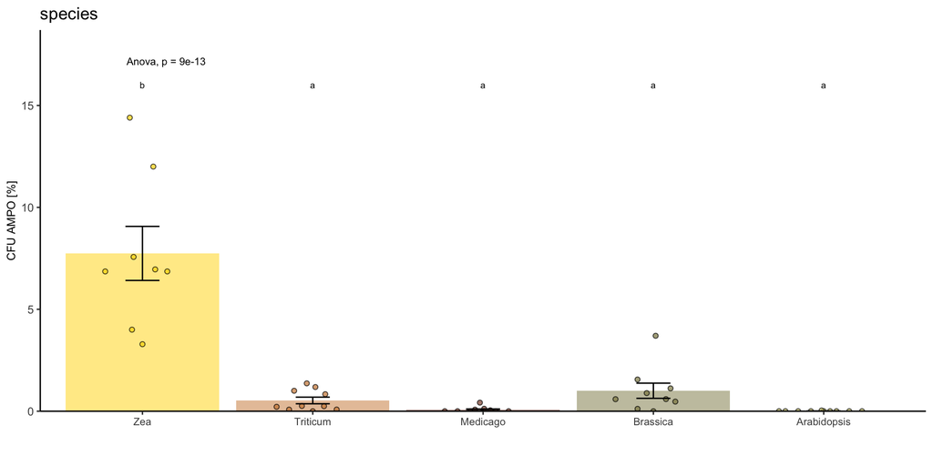